# Machine Learning Course Project

Lyle McMillin

July 16, 2016

### Overview

#### Background

Using devices such as Jawbone Up, Nike FuelBand, and Fitbit it is now possible to collect a large amount of data about personal activity relatively inexpensively. These type of devices are part of the quantified self movement – a group of enthusiasts who take measurements about themselves regularly to improve their health, to find patterns in their behavior, or because they are tech geeks. One thing that people regularly do is quantify how much of a particular activity they do, but they rarely quantify how well they do it.

#### Project Objective

The goal of this project is to use data from accelerometers on the belt, forearm, arm and dumbbell of 6 participants to predict the manner in which they did the exercise (indicated by the “classe” variable in the training dataset).

#### Data Source

The data for this project was provided by:

Ugulino, W.; Cardador, D.; Vega, K.; Velloso, E.; Milidiu, R.; Fuks, H. Wearable Computing: Accelerometers’ Data Classification of Body Postures and Movements. Proceedings of 21st Brazilian Symposium on Artificial Intelligence. Advances in Artificial Intelligence - SBIA 2012. In: Lecture Notes in Computer Science. , pp. 52-61. Curitiba, PR: Springer Berlin / Heidelberg, 2012. ISBN 978-3-642-34458-9. DOI: 10.1007/978-3-642-34459-6_6.

Read more: http://groupware.les.inf.puc-rio.br/har#ixzz4EbEkCdnh

## Data Analysis

### Libraries

Load any required libraries.

```r
suppressMessages(library(dplyr))
suppressMessages(library(ggplot2))
suppressMessages(library(caret))
```

### Load the data

Read the training and testing data into the “pml-training” and “pml-testing” data sets.

```r
pml.train.dat <- read.csv("dat/pml-training.csv", stringsAsFactors = FALSE)
pml.test.dat <- read.csv("dat/pml-testing.csv", stringsAsFactors = FALSE)

#Convert all of the middle columns to numeric
pml.train.dat[,7:159] <- as.numeric(unlist(pml.train.dat[,7:159]))
pml.test.dat[,7:159] <- as.numeric(unlist(pml.test.dat[,7:159]))
```

### Data Exploration

```r
dim(pml.train.dat)
```

```
## [1] 19622   160
```

```r
str(pml.train.dat)
```

```
## 'data.frame':    19622 obs. of  160 variables:
##  $ X                       : int  1 2 3 4 5 6 7 8 9 10 ...
##  $ user_name               : chr  "carlitos" "carlitos" "carlitos" "carlitos" ...
##  $ raw_timestamp_part_1    : int  1323084231 1323084231 1323084231 1323084232 1323084232 1323084232 1323084232 1323084232 1323084232 1323084232 ...
##  $ raw_timestamp_part_2    : int  788290 808298 820366 120339 196328 304277 368296 440390 484323 484434 ...
##  $ cvtd_timestamp          : chr  "05/12/2011 11:23" "05/12/2011 11:23" "05/12/2011 11:23" "05/12/2011 11:23" ...
##  $ new_window              : chr  "no" "no" "no" "no" ...
##  $ num_window              : num  11 11 11 12 12 12 12 12 12 12 ...
##  $ roll_belt               : num  1.41 1.41 1.42 1.48 1.48 1.45 1.42 1.42 1.43 1.45 ...
##  $ pitch_belt              : num  8.07 8.07 8.07 8.05 8.07 8.06 8.09 8.13 8.16 8.17 ...
##  $ yaw_belt                : num  -94.4 -94.4 -94.4 -94.4 -94.4 -94.4 -94.4 -94.4 -94.4 -94.4 ...
##  $ total_accel_belt        : num  3 3 3 3 3 3 3 3 3 3 ...
##  $ kurtosis_roll_belt      : num  NA NA NA NA NA NA NA NA NA NA ...
##  $ kurtosis_picth_belt     : num  NA NA NA NA NA NA NA NA NA NA ...
##  $ kurtosis_yaw_belt       : num  NA NA NA NA NA NA NA NA NA NA ...
```

[output cut: 86 more lines]

It appears that many of the variables are very heavy with NAs. I am going to run a count of NAs per column to determin the extent of their presense.

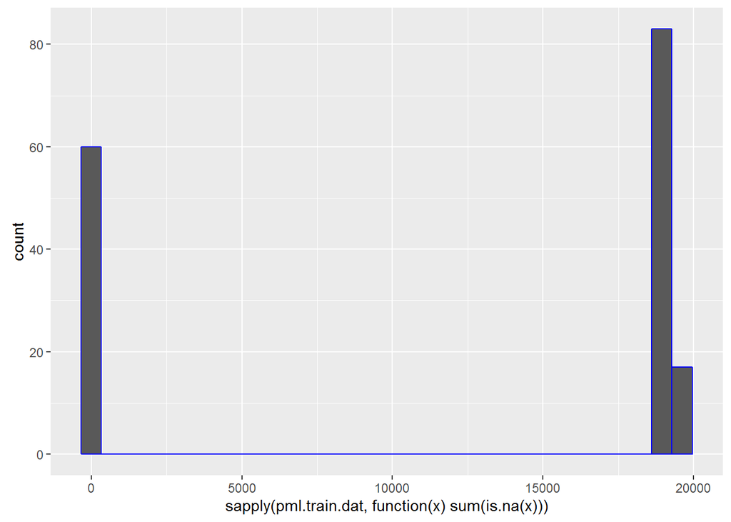

```r
qplot(sapply(pml.train.dat, function(x) sum(is.na(x))), geom = "histogram", col = I("blue"))
```

The above graph shows that many of the columns have a significant number of NAs. To aid in my predictor selection I will now create a for loop to remove those columns from my analysis as imputation will most likely not be an option for those columns.

```r
#vector count variable
ct <- 1
remove.col <- as.vector(0)
per.na <- .9 * nrow(pml.train.dat)

for (i in 1:ncol(pml.train.dat)) {
        num.na <- NULL
        #threshold of NAs per column based off of percentage

        num.na <- sum(is.na(pml.train.dat[,i]))
        if (!is.null(num.na)) {
                if (num.na > per.na) {
                        remove.col[ct] <- i#names(pml.train.dat)[i]
                        ct <- ct + 1
                }
        }
}
```

There were 100 columns that contained NAs in excess of 90%. Those columns will be removed before selecting predictors.

```r
#Removing columns from pml.train.dat
pml.train.dat <- pml.train.dat[,-remove.col]
```

For the purposes of my analysis, I am going to split the “pml.training.dat” dataset again to create another testing set.

```r
pml.data.sep <- createDataPartition(pml.train.dat$classe, p = .8, list = FALSE)
pml.train.dat.1 <- pml.train.dat[pml.data.sep,]
pml.train.dat.2 <- pml.train.dat[-pml.data.sep,]
```

## Predictor Analysis

I will now seek to select predictors for my model. First I will analyze the importance of each variable to determine which variables should be included in my initial test.

```r
set.seed(1000)

control <- rfeControl(functions=rfFuncs, method="cv", number=10)

pred.results <- rfe(pml.train.dat.1[,8:59], as.factor(pml.train.dat.1[,60]), rfeControl=control)

print(pred.results)
```

```
##
## Recursive feature selection
##
## Outer resampling method: Cross-Validated (10 fold)
##
## Resampling performance over subset size:
##
##  Variables Accuracy  Kappa AccuracySD  KappaSD Selected
##          4   0.9462 0.9320   0.006695 0.008461
##          8   0.9867 0.9832   0.002593 0.003279
##         16   0.9917 0.9895   0.002651 0.003354
##         52   0.9955 0.9944   0.002267 0.002868        *
##
## The top 5 variables (out of 52):
##    roll_belt, yaw_belt, magnet_dumbbell_z, pitch_belt, magnet_dumbbell_y
```

Based off of these results, it appears that 4 variables will deliver almost 95% accurracy and 8 variables will deliver over 98% accuracy.

The following graph shows a significan gain to be had using the Top 10 variables. For the next round of testing, I will chose the Top 10 variables. In my training set I will enable cross validation to filter my predictors down from there.

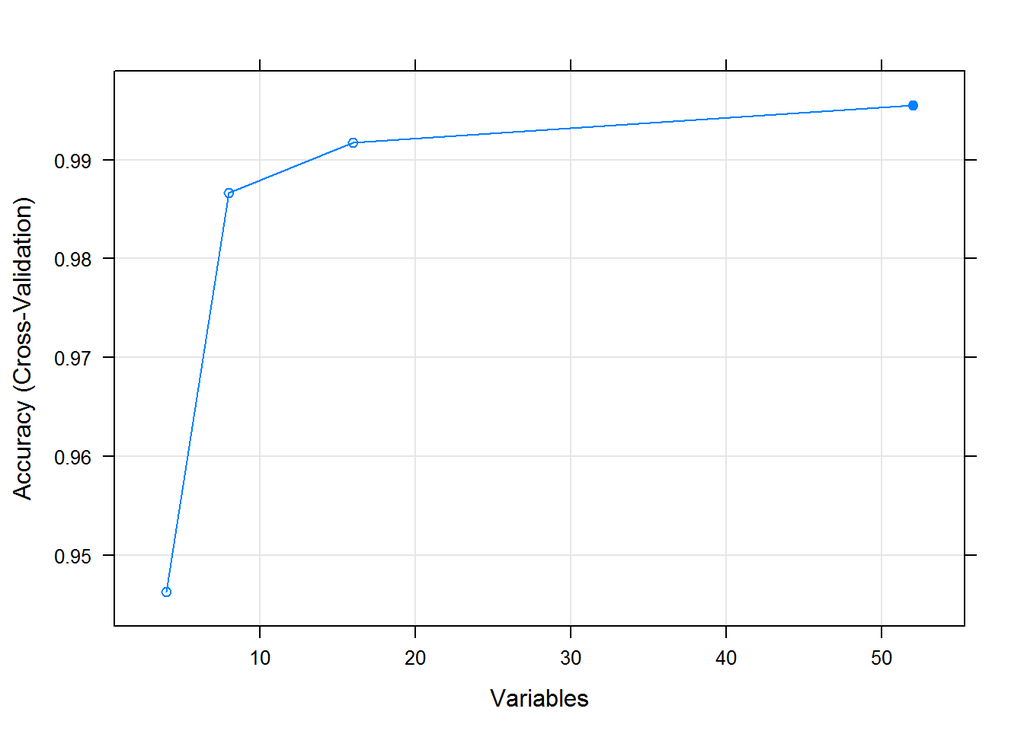

```r
plot(pred.results, type = c("g", "o"))
```

## Model Building

For this exercise, I will build a model using the top 10 variables from my test and fitting the model using random forests. Cross validation will be enable in the training control to provide further feedback as to the effectiveness of my model.

Those variables are: roll_belt, yaw_belt, magnet_dumbbell_z, pitch_belt, magnet_dumbbell_y, pitch_forearm, accel_dumbbell_y, roll_forearm, magnet_forearm_z, roll_dumbbell.

```r
pml.modfit <- train(classe ~ roll_belt + yaw_belt + magnet_dumbbell_z + pitch_belt + magnet_dumbbell_y + pitch_forearm + accel_dumbbell_y + roll_forearm + roll_dumbbell + magnet_forearm_z, method = "rf", data = pml.train.dat.1, trControl = trainControl(method = "cv"))

pml.modfit
```

[output not shown]

## Prediction

I will now predict using the first test set (taken from the original training set).

```r
pml.predict <- suppressMessages(predict(pml.modfit, newdata = pml.train.dat.2))

confusionMatrix(pml.predict, pml.train.dat.2$classe)
```

```
## Confusion Matrix and Statistics
##
##           Reference
## Prediction    A    B    C    D    E
##          A 1114    0    0    0    0
##          B    0  755    0    0    0
##          C    1    4  683    3    1
##          D    1    0    1  639    0
##          E    0    0    0    1  720
##
## Overall Statistics
##
##                Accuracy : 0.9969
##                  95% CI : (0.9947, 0.9984)
##     No Information Rate : 0.2845
##     P-Value [Acc > NIR] : < 2.2e-16
##
##                   Kappa : 0.9961
##  Mcnemar's Test P-Value : NA
##
## Statistics by Class:
##
##                      Class: A Class: B Class: C Class: D Class: E
## Sensitivity            0.9982   0.9947   0.9985   0.9938   0.9986
## Specificity            1.0000   1.0000   0.9972   0.9994   0.9997
## Pos Pred Value         1.0000   1.0000   0.9870   0.9969   0.9986
## Neg Pred Value         0.9993   0.9987   0.9997   0.9988   0.9997
## Prevalence             0.2845   0.1935   0.1744   0.1639   0.1838
## Detection Rate         0.2840   0.1925   0.1741   0.1629   0.1835
## Detection Prevalence   0.2840   0.1925   0.1764   0.1634   0.1838
## Balanced Accuracy      0.9991   0.9974   0.9979   0.9966   0.9992
```

## Conclusion

### First Test Results

The results show that this model is producing 99% accuracy on the first test set (a subset of the original training set). These results are in line with the estimates set for in the cross validation exercise.

With this results I am confident that I now have the correct model to proceed to the official testing set.

### Final Predictions

Below are the final predictions based off of the test set using the pml.modfit model.

```r
final.test.predict <- predict(pml.modfit, newdata = pml.test.dat)

final.test.predict
```

```
##  [1] B A B A A E D B A A B C B A E E A B B B
## Levels: A B C D E
```